# Data Visualization: `ggplot` part 2

## Learning Goals

*At the end of this exercise, you will be able to:*  
1. Produce box plots using `ggplot.`  
2. Customize labels on axes using `labs` and `themes`.  
3. Use `color`, `fill`, and `group` to customize plots and improve overall aesthetics.

## Review

Now that you have been introduced to `ggplot`, let’s review the plot types from last week and learn how to manipulate their aesthetics to better suit our needs. Aesthetics make a significant difference, but you can take it too far so remember that the goal is to produce clean plots that are not distracting.

##Resources - [ggplot2 cheatsheet](https://www.rstudio.com/wp-content/uploads/2015/03/ggplot2-cheatsheet.pdf) - [`ggplot` themes](https://ggplot2.tidyverse.org/reference/ggtheme.html) - [Rebecca Barter `ggplot` Tutorial](http://www.rebeccabarter.com/blog/2017-11-17-ggplot2_tutorial/)

## Load the libraries

```r
library(tidyverse)
library(here)
library(janitor)
```

## Load the data

Let’s revisit the mammal life history data to practice our ggplot skills. The [data](http://esapubs.org/archive/ecol/E084/093/) are from: *S. K. Morgan Ernest. 2003. Life history characteristics of placental non-volant mammals. Ecology 84:3402.*

```r
life_history <- read_csv(here("lab10", "data", "mammal_lifehistories_v2.csv")) %>% na_if("-999") %>% clean_names() #Common input string
```

```r
glimpse(life_history)
```

```
## Rows: 1,440
## Columns: 13
## $ order        <chr> "Artiodactyla", "Artiodactyla", "Artiodactyla", "Artioda…
## $ family       <chr> "Antilocapridae", "Bovidae", "Bovidae", "Bovidae", "Bovi…
## $ genus        <chr> "Antilocapra", "Addax", "Aepyceros", "Alcelaphus", "Ammo…
## $ species      <chr> "americana", "nasomaculatus", "melampus", "buselaphus", …
## $ mass         <dbl> 45375.0, 182375.0, 41480.0, 150000.0, 28500.0, 55500.0, …
## $ gestation    <dbl> 8.13, 9.39, 6.35, 7.90, 6.80, 5.08, 5.72, 5.50, 8.93, 9.…
## $ newborn      <dbl> 3246.36, 5480.00, 5093.00, 10166.67, NA, 3810.00, 3910.0…
## $ weaning      <dbl> 3.00, 6.50, 5.63, 6.50, NA, 4.00, 4.04, 2.13, 10.71, 6.6…
## $ wean_mass    <dbl> 8900, NA, 15900, NA, NA, NA, NA, NA, 157500, NA, NA, NA,…
## $ afr          <dbl> 13.53, 27.27, 16.66, 23.02, NA, 14.89, 10.23, 20.13, 29.…
## $ max_life     <dbl> 142, 308, 213, 240, NA, 251, 228, 255, 300, 324, 300, 31…
## $ litter_size  <dbl> 1.85, 1.00, 1.00, 1.00, 1.00, 1.37, 1.00, 1.00, 1.00, 1.…
## $ litters_year <dbl> 1.00, 0.99, 0.95, NA, NA, 2.00, NA, 1.89, 1.00, 1.00, 0.…
```

## Bar Plots

Bar plots count the number of observations in a categorical variable.

```r
life_history %>%
  count(order, sort=T) #How many observations we have in each taxonomic order
```

```
## # A tibble: 17 x 2
##    order              n
##    <chr>          <int>
##  1 Rodentia         665
##  2 Carnivora        197
##  3 Artiodactyla     161
##  4 Primates         156
##  5 Insectivora       91
##  6 Cetacea           55
##  7 Lagomorpha        42
##  8 Xenarthra         20
##  9 Perissodactyla    15
## 10 Macroscelidea     10
## 11 Pholidota          7
## 12 Scandentia         7
## 13 Sirenia            5
## 14 Hyracoidea         4
## 15 Dermoptera         2
## 16 Proboscidea        2
## 17 Tubulidentata      1
```

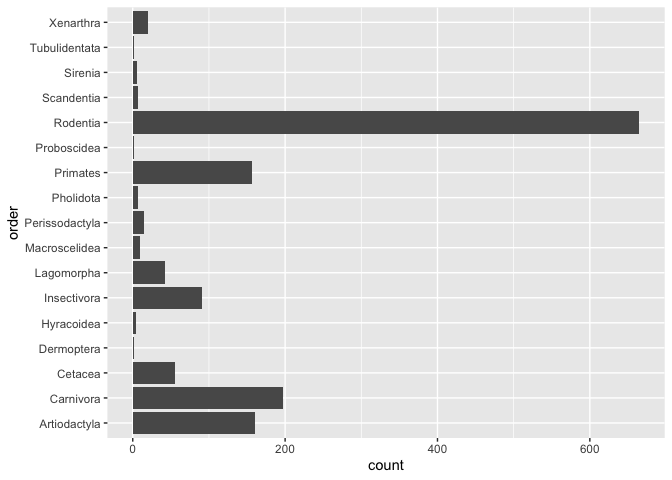

```r
life_history %>%
  ggplot(aes(x=order)) + geom_bar()+coord_flip() #Not adding anything to y axis
```

```r
#This is regarding thinking about difference between geom_bar and geom_call. Geom_call: specify an x and y axis. only asking R to count number of unique observations together. ex. Rodents all in one count, etc. This is the above graph. This next code is looking at the order column, taking all of the taxonomic numbers and combining their numbers together
life_history %>%
  group_by(order) %>%
  summarize(mean_mass=mean(mass, na.rm=T))
```

```
## # A tibble: 17 x 2
##    order          mean_mass
##  * <chr>              <dbl>
##  1 Artiodactyla     115843.
##  2 Carnivora         43382.
##  3 Cetacea         9830457.
##  4 Dermoptera         1000
##  5 Hyracoidea         3031.
##  6 Insectivora         133.
##  7 Lagomorpha         1702.
##  8 Macroscelidea       124.
##  9 Perissodactyla   694487.
## 10 Pholidota          7980
## 11 Primates           5145.
## 12 Proboscidea     3342500
## 13 Rodentia            637.
## 14 Scandentia          389.
## 15 Sirenia         1169400
## 16 Tubulidentata     60000
## 17 Xenarthra          7238.
```

```r
#Mean mass of each of the groups. Order is x, mean_mass is y
```

```r
options(scipen=999) #cancels scientific notation for the session
```

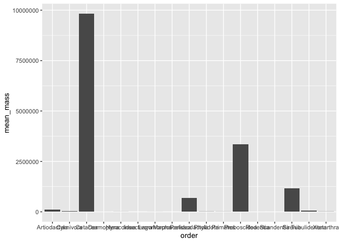

```r
life_history %>%
  group_by(order) %>%
  summarize(mean_mass=mean(mass, na.rm=T)) %>%
  ggplot(aes(x=order, y=mean_mass))+geom_col()
```

```r
#Additional problem where everything is in scientific notation. The numbers are pretty big, so we need to manually turn this off in RStudio
```

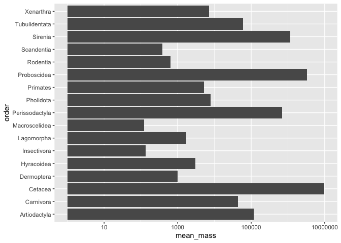

```r
life_history %>%
  group_by(order) %>%
  summarize(mean_mass=mean(mass, na.rm=T)) %>%
  ggplot(aes(x=order, y=mean_mass))+geom_col()+coord_flip()+scale_y_log10()
```

```r
#Scaling everything with log10 helps keep everything on an easier scale (ex. comparing rodents to whales)
```

## Scatterplots

Scatter plots allow for comparisons of two continuous variables. (Leaving categorical variables behind for now)

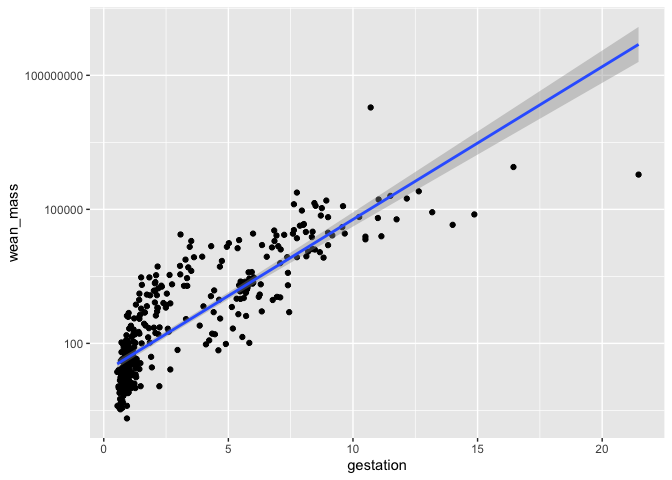

```r
life_history %>%
  ggplot(aes(x=gestation, y=wean_mass)) + geom_point(na.rm=T) + scale_y_log10() + geom_smooth(method="lm")
```

```r
#Does wean mass have any correlation with gestation? Assume positive correlation. Longer baby stays in tummy, larger mass
#Geom_point is scatter plot, remove NAs if they're there
#Adding line of best fit: geom_smooth(method="lm"), lm is "linear model"
```

## Boxplots

Box plots help us visualize a range of values. So, on the x-axis we typically have something categorical and the y-axis is the range.

```r
glimpse(life_history)
```

```
## Rows: 1,440
## Columns: 13
## $ order        <chr> "Artiodactyla", "Artiodactyla", "Artiodactyla", "Artioda…
## $ family       <chr> "Antilocapridae", "Bovidae", "Bovidae", "Bovidae", "Bovi…
## $ genus        <chr> "Antilocapra", "Addax", "Aepyceros", "Alcelaphus", "Ammo…
## $ species      <chr> "americana", "nasomaculatus", "melampus", "buselaphus", …
## $ mass         <dbl> 45375.0, 182375.0, 41480.0, 150000.0, 28500.0, 55500.0, …
## $ gestation    <dbl> 8.13, 9.39, 6.35, 7.90, 6.80, 5.08, 5.72, 5.50, 8.93, 9.…
## $ newborn      <dbl> 3246.36, 5480.00, 5093.00, 10166.67, NA, 3810.00, 3910.0…
## $ weaning      <dbl> 3.00, 6.50, 5.63, 6.50, NA, 4.00, 4.04, 2.13, 10.71, 6.6…
## $ wean_mass    <dbl> 8900, NA, 15900, NA, NA, NA, NA, NA, 157500, NA, NA, NA,…
## $ afr          <dbl> 13.53, 27.27, 16.66, 23.02, NA, 14.89, 10.23, 20.13, 29.…
## $ max_life     <dbl> 142, 308, 213, 240, NA, 251, 228, 255, 300, 324, 300, 31…
## $ litter_size  <dbl> 1.85, 1.00, 1.00, 1.00, 1.00, 1.37, 1.00, 1.00, 1.00, 1.…
## $ litters_year <dbl> 1.00, 0.99, 0.95, NA, NA, 2.00, NA, 1.89, 1.00, 1.00, 0.…
```

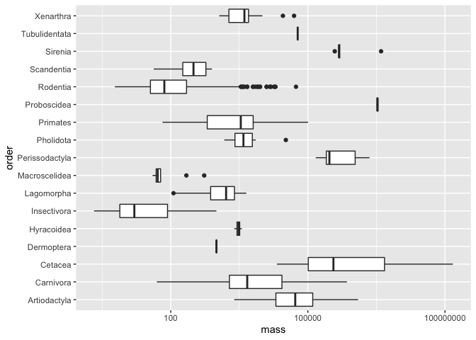

```r
life_history %>%
  ggplot(aes(x=order, y=mass))+geom_boxplot()+scale_y_log10()+coord_flip()
```

```r
#Gives idea of various ranges. Maybe certain orders in this list are of interest. You can use dplier functions to do this in the next example!
```

Remember, you can always use dplyr functions to focus your question, summarize, etc.

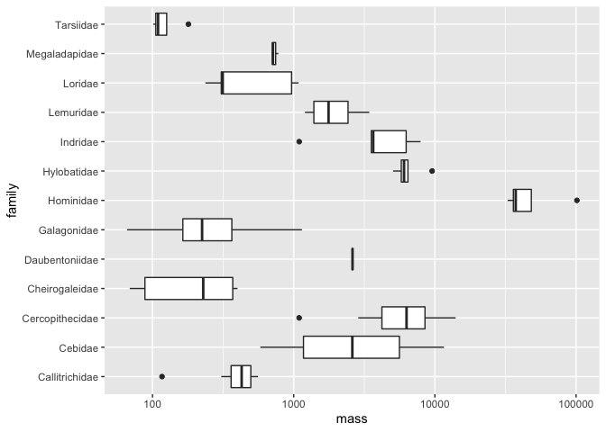

```r
life_history %>%
  filter(order=="Primates") %>%
  ggplot(aes(x=family, y=mass))+geom_boxplot(na.rm=T)+scale_y_log10()+coord_flip()
```

```r
#Change aes to (x=family, y=mass)
#Na.rm=T removes warning/error about weird values being in there
```

## Practice

For this practice, let’s go back to the elephants data from midterm 1. Maybe we can make our midterm answers “pop” with some nice plots!

```r
elephants <- read_csv(here("lab10", "data", "ElephantsMF.csv")) %>% clean_names()
```

1. On midterm 1, I asked how many male and female elephants were represented in the data. How would you make a plot of this?

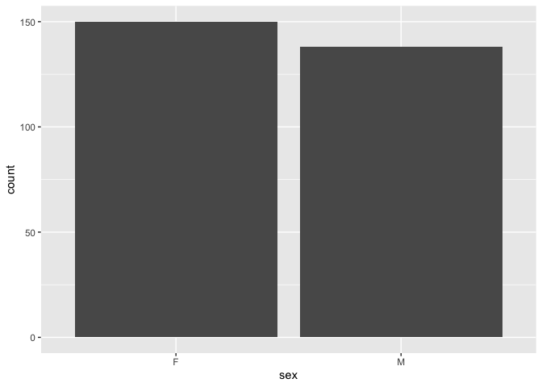

```r
elephants %>%
  ggplot(aes(x=sex))+geom_bar()
```

```r
  #If this is a count, it's going to be bar plot
```

2. How does the age of elephants compare by sex?

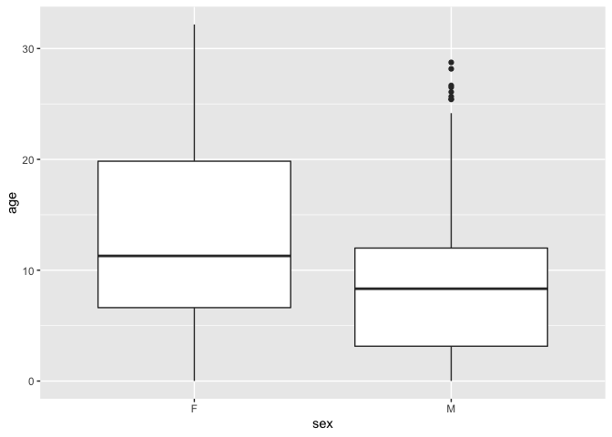

```r
#Now talking about range, so boxplot
elephants %>%
  ggplot(aes(x=sex, y=age))+geom_boxplot()
```

3. What is the relationship between age and height?

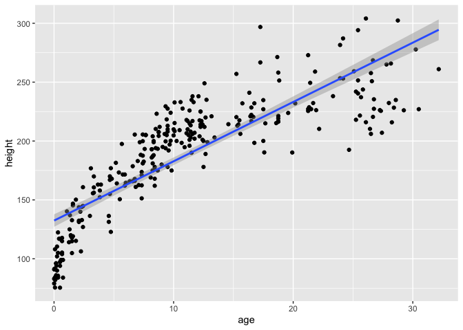

```r
elephants %>%
  ggplot(aes(x=age, y=height))+geom_point()+geom_smooth(method="lm")
```